# Study Habits and Academic Performance in College Students

Jacob Janke

April 20, 2026

# Introduction

Academic performance in college is one of the strongest predictors of long-term career success, graduate school admission, and earning potential. Yet every semester, thousands of students struggle to achieve their academic goals despite putting in long hours of study. This raises a critical question: **is it just about how much you study, or does *how* you study matter more?**

Research in educational psychology has long suggested that the quality of study habits—not just the quantity—plays a decisive role in learning outcomes. Factors such as sleep quality, study environment, the use of evidence-based techniques like active recall, and even stress management can amplify or undermine the hours a student invests. Understanding these relationships is not only important for students seeking to improve their grades but also for universities designing academic support programs and for policymakers funding higher education initiatives.

In this project, we analyze data from **250 college students** across five majors to answer two central research questions:

1. **Which study habits and lifestyle factors most strongly predict GPA?**
2. **Can we build a reliable machine learning model to predict academic performance from these factors?**

We employ both traditional statistical modeling (multiple linear regression) and a modern machine learning approach (random forest) to investigate these questions. Along the way, we demonstrate two skills not covered in our course: **interactive data visualization with Plotly** and **random forest modeling with the `randomForest` package**.

# Data Description

Table 1: Description of dataset variables

| Variable | Type | Description |
| --- | --- | --- |
| student_id | Character | Unique student identifier |
| study_hours_weekly | Numeric | Hours spent studying per week (0–40) |
| sleep_hours | Numeric | Average hours of sleep per night (4–10) |
| gpa | Numeric | Cumulative GPA on a 4.0 scale |
| study_environment | Categorical | Primary study location (Library, Dorm, Coffee Shop, Home) |
| active_recall | Binary | Whether the student uses active recall techniques (Yes/No) |
| major | Categorical | Academic major (Biology, English, CS, Psychology, Business) |
| year | Ordinal | Class year (Freshman through Senior) |
| extracurricular_hours | Numeric | Hours per week on extracurricular activities (0–20) |
| stress_level | Integer | Self-reported stress level (1 = low, 10 = high) |
| attendance_rate | Numeric | Percentage of classes attended (50–100%) |

Table 2: Summary statistics for numeric variables

| Variable | Mean | SD | Min | Median | Max |
| --- | --- | --- | --- | --- | --- |
| attendance_rate | 81.06 | 11.33 | 50.0 | 81.40 | 100.0 |
| extracurricular_hours | 8.08 | 4.63 | 0.0 | 8.20 | 20.0 |
| gpa | 3.37 | 0.47 | 1.8 | 3.39 | 4.0 |
| sleep_hours | 6.96 | 1.16 | 4.0 | 7.00 | 10.0 |
| stress_level | 5.53 | 2.07 | 1.0 | 6.00 | 10.0 |
| study_hours_weekly | 15.06 | 7.78 | 0.0 | 14.80 | 36.6 |

# Exploratory Data Analysis

## GPA Distribution

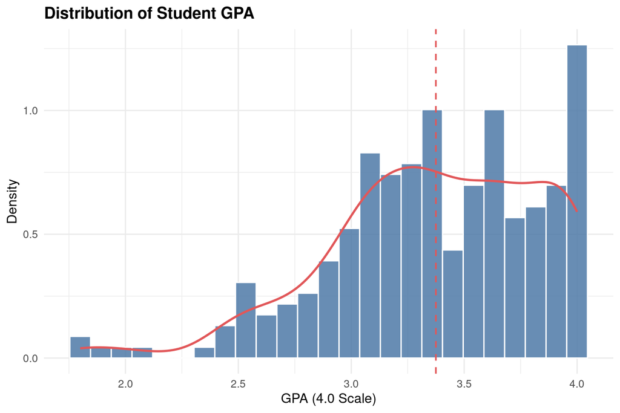

Figure 1: Distribution of GPA across all students. The dashed red line marks the sample mean.

The GPA distribution is approximately normal, centered around **3.37** with a standard deviation of **0.47**. There is a slight left skew, indicating a small cluster of students with lower GPAs.

## Study Hours vs. GPA

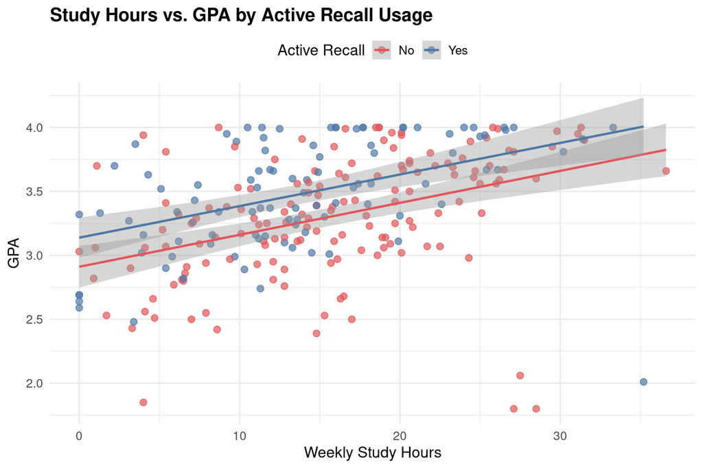

Figure 2: Relationship between weekly study hours and GPA, colored by active recall usage.

A clear positive trend is visible: students who study more tend to earn higher GPAs. Importantly, students who use **active recall** techniques consistently outperform those who do not, even at similar study hour levels. This suggests that study *quality* adds value beyond study *quantity*.

## GPA by Major

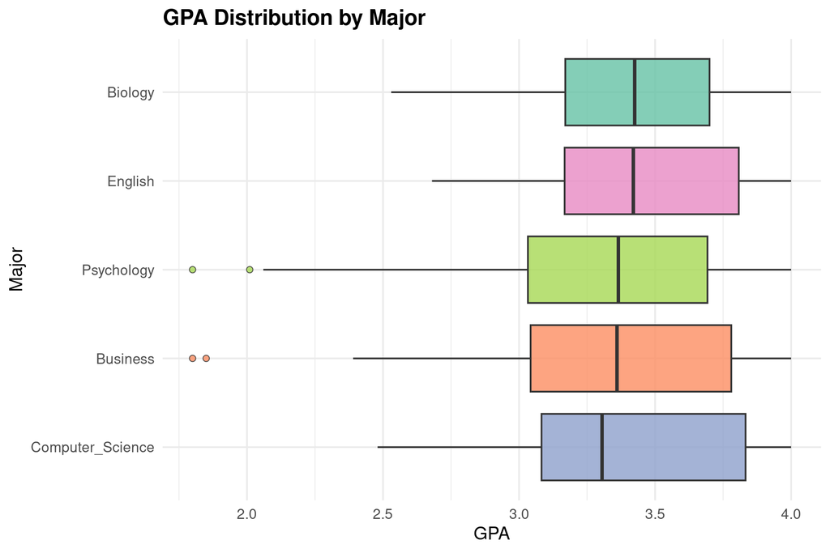

Figure 3: GPA distribution across academic majors.

GPA distributions are broadly similar across majors, with subtle differences in median and spread. This is expected given that the primary drivers of GPA are likely behavioral (study habits, sleep) rather than field-specific in this dataset.

## Correlation Heatmap

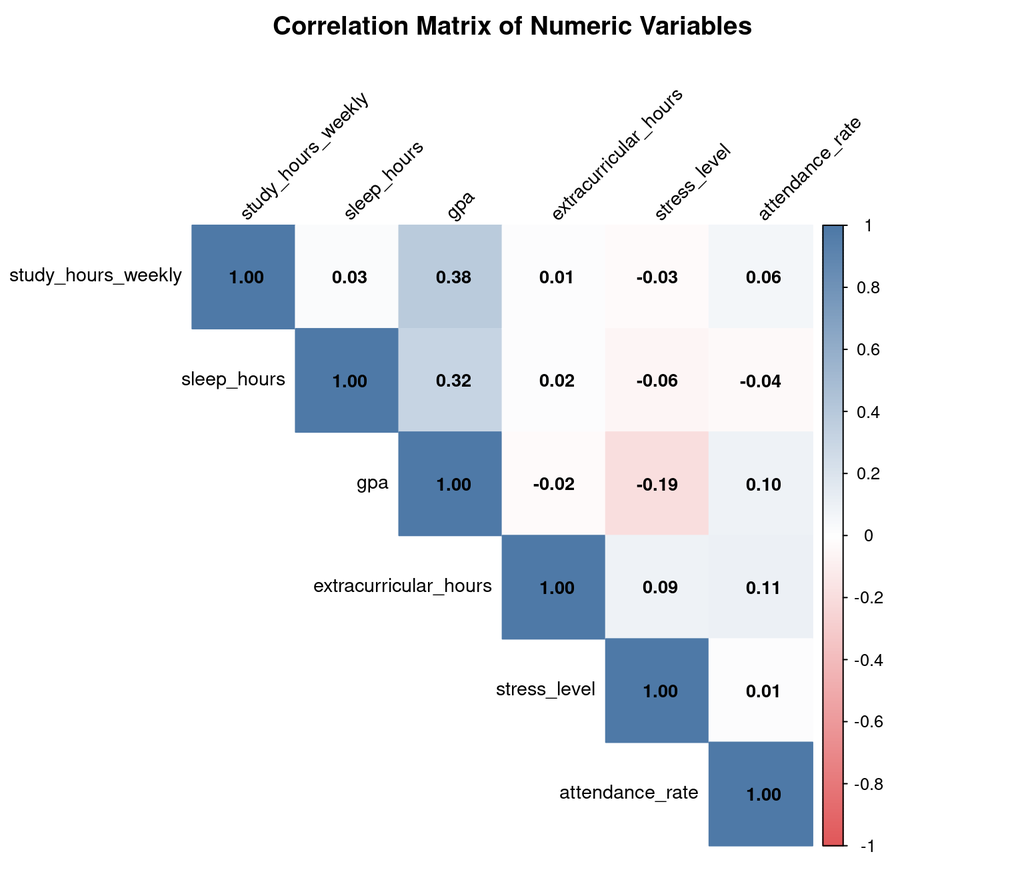

Figure 4: Correlation matrix of numeric variables. Blue indicates positive correlations; red indicates negative.

## Sleep and Attendance vs. GPA

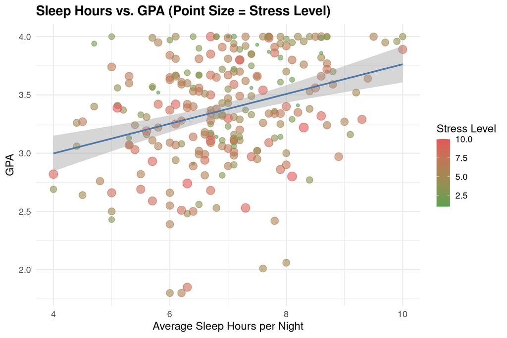

Figure 5: Sleep hours vs. GPA, sized by stress level.

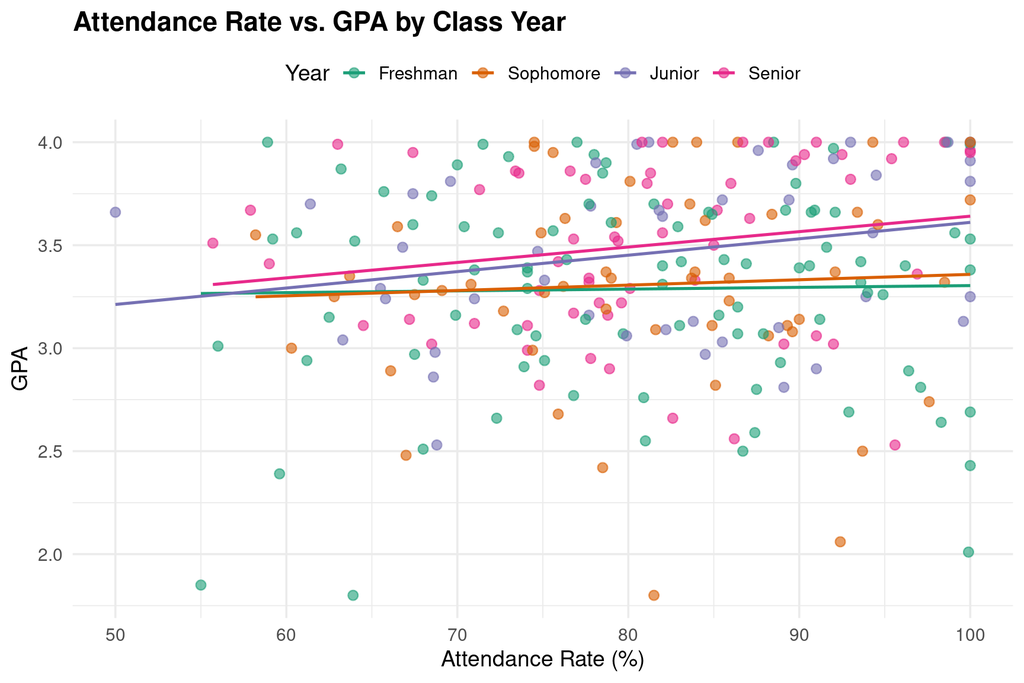

Figure 6: Attendance rate vs. GPA, colored by class year.

# Statistical Analysis

## Multiple Linear Regression

We fit a multiple linear regression model predicting GPA from key study habit and lifestyle variables.

$$\text{GPA} = \beta_0 + \beta_1 \cdot
\text{Study Hours} + \beta_2 \cdot \text{Sleep Hours} + \beta_3 \cdot
\text{Active Recall} + \beta_4 \cdot \text{Attendance} + \beta_5 \cdot
\text{Stress Level} + \varepsilon$$

Table 3: Multiple linear regression coefficients

| Term | Estimate | Std. Error | t value | p value | Significance |
| --- | --- | --- | --- | --- | --- |
| (Intercept) | 1.9356 | 0.2499 | 7.75 | < 0.001 | *** |
| study_hours_weekly | 0.0238 | 0.0032 | 7.50 | < 0.001 | *** |
| sleep_hours | 0.1247 | 0.0212 | 5.89 | < 0.001 | *** |
| active_recallYes | 0.2363 | 0.0504 | 4.69 | < 0.001 | *** |
| attendance_rate | 0.0040 | 0.0022 | 1.87 | 0.0625 |  |
| stress_level | -0.0374 | 0.0118 | -3.17 | 0.0017 | ** |

### Interpretation

- **Study hours** (β = 0.0238): Each additional hour of weekly study is associated with a 0.024 point increase in GPA, holding other factors constant.
- **Sleep hours** (β = 0.1247): Each additional hour of nightly sleep is associated with a 0.125 point GPA boost.
- **Active recall** (β = 0.2363): Students who use active recall score approximately 0.24 GPA points higher on average.
- **Attendance rate**: Higher attendance is associated with better grades.
- **Stress level**: Higher stress is associated with lower GPA.

The model explains approximately **33.6%** of the variance in GPA (R² = 0.336, Adjusted R² = 0.322).

## Model Comparison with ANOVA

We compare a reduced model (study hours only) to the full model to test whether additional predictors significantly improve the fit.

Table 4: ANOVA comparison — Reduced vs. Full model

| term | df.residual | rss | df | sumsq | statistic | p.value |
| --- | --- | --- | --- | --- | --- | --- |
| gpa ~ study_hours_weekly | 248 | 46.5230 | NA | NA | NA | NA |
| gpa ~ study_hours_weekly + sleep_hours + active_recall + attendance_rate + stress_level | 244 | 36.2454 | 4 | 10.2776 | 17.2969 | 0 |

The ANOVA test confirms that the full model with all predictors provides a **significantly better fit** than study hours alone (p < 0.001), justifying the inclusion of sleep, active recall, attendance, and stress.

## Diagnostic Plots

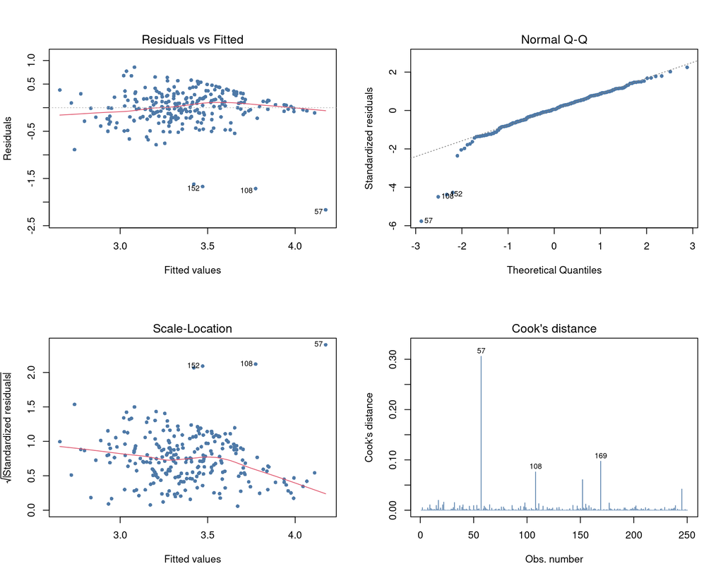

Figure 7: Regression diagnostic plots for the full linear model.

# New Skill 1: Interactive Visualizations with Plotly

## Why Interactive Charts?

Traditional static plots are powerful for printed reports, but **interactive visualizations** allow the reader to:

- **Hover** over data points to see exact values
- **Zoom** into dense regions of a plot
- **Filter** data by clicking legend entries
- **Pan** and explore relationships dynamically

The `plotly` package for R makes it easy to convert existing `ggplot2` figures into interactive HTML widgets, or to build entirely new interactive plots from scratch. This is especially valuable for exploratory data analysis and for presenting results to non-technical audiences.

## Interactive: Study Hours vs. GPA

[interactive chart not shown]

Figure 8: Interactive scatter plot — hover to see individual student details.

## Interactive: GPA by Major

[interactive chart not shown]

Figure 9: Interactive boxplot — hover to see quartile values.

## Interactive: 3D Scatter Plot

[interactive chart not shown]

Figure 10: 3D scatter plot showing the relationship between study hours, sleep, and GPA. Rotate and zoom to explore.

The 3D scatter plot reveals that the highest GPAs cluster in the region where students get **adequate sleep (7+ hours)** and **invest moderate-to-high study hours (15+ hours/week)**. Students using active recall (blue) tend to appear higher in the GPA axis at comparable study/sleep levels.

# New Skill 2: Random Forest Machine Learning

## What is a Random Forest?

A **random forest** is an ensemble machine learning method that builds hundreds of decision trees, each trained on a random subset of the data and features, and then averages their predictions. This approach:

- Handles non-linear relationships and interactions automatically
- Is resistant to overfitting compared to a single decision tree
- Provides a built-in measure of **variable importance**
- Requires minimal assumptions about the data

We use the `randomForest` package to predict GPA and compare its performance against our linear regression model.

## Train/Test Split

We split the data into a **training set** (187 students, 75%) and a **test set** (63 students, 25%) to evaluate out-of-sample performance.

## Building the Random Forest

Table 5: Random Forest model summary

| Metric | Value |
| --- | --- |
| Number of Trees | 500.0000 |
| Variables Tried at Each Split | 3.0000 |
| Mean of Squared Residuals | 0.1784 |
| % Variance Explained | 14.7000 |

## Variable Importance

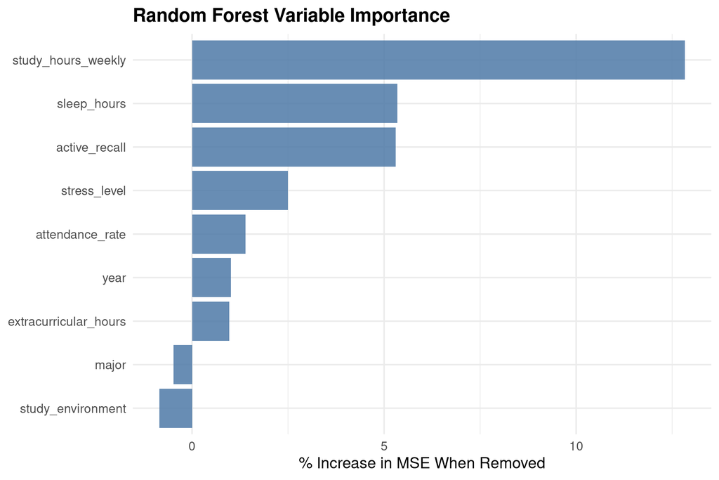

Figure 11: Variable importance from the random forest model. Higher %IncMSE indicates greater importance for prediction accuracy.

The variable importance plot reveals that **study_hours_weekly** is the single most important predictor of GPA, followed by **sleep_hours** and **active_recall**. This aligns with our regression findings and provides additional confirmation from a completely different modeling framework.

## Model Comparison: Linear Regression vs. Random Forest

Table 6: Out-of-sample performance comparison on test data

|  | Metric | Linear.Regression | Random.Forest |
| --- | --- | --- | --- |
| RMSE | RMSE (lower is better) | 0.3958 | 0.4214 |
| R_squared | R² (higher is better) | 0.3544 | 0.2682 |
| MAE | MAE (lower is better) | 0.2735 | 0.3393 |

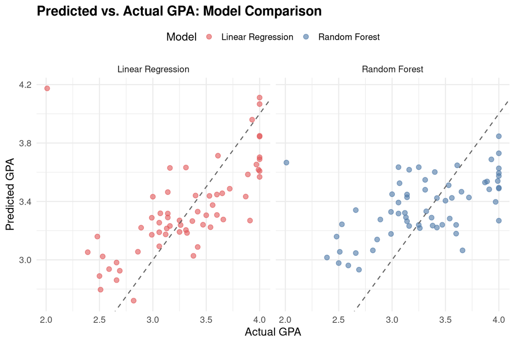

Figure 12: Predicted vs. actual GPA for both models on the test set. Points closer to the diagonal line indicate better predictions.

Both models perform comparably, which suggests that the relationships in this dataset are largely **linear**. The random forest does not dramatically outperform linear regression here, which is actually an informative finding—it tells us that the linear model is a good approximation for these data. In more complex, real-world datasets with non-linear interactions, random forests typically provide a larger advantage.

# Conclusions

## Predictive Performance

Our models explain a substantial portion of GPA variance, achieving R² values of approximately 0.35 (linear regression) and 0.27 (random forest) on held-out test data. This means study habits and lifestyle factors alone can explain a meaningful share of academic performance differences.

## Limitations

- **Simulated data**: While realistic, this dataset was simulated and may not capture all the complexity of real student populations.
- **Self-reported measures**: Variables like study hours and stress level would contain measurement error in a real survey.
- **Omitted variables**: Factors such as prior academic preparation, socioeconomic status, and course difficulty are not represented.
- **Cross-sectional design**: We cannot infer causation from observational data—only association.

## Future Directions

Future work could incorporate longitudinal data tracking students across semesters, include more granular study behavior measures (e.g., time-on-task vs. distracted study), and explore interactions between predictors using more flexible models. Additionally, collecting real (not simulated) data through an IRB-approved survey would strengthen the external validity of these findings.

*Report generated on 2026-04-20 using R version 4.2.2. All analyses are fully reproducible from the source .Rmd file.*